# Praca domowa 2

## Zadanie 6

Rozważmy osoby, które są bezrobotne albo ich zawód jest nieznany. Czy procent osób, które są bezrobotne i nie spłacają kredytu jest większy od procenta osób o nieznanym zawodzie i nie spłacanym kredycie? Jaki typ kredytu jest (przez te osoby) najczęściej niespłacany?

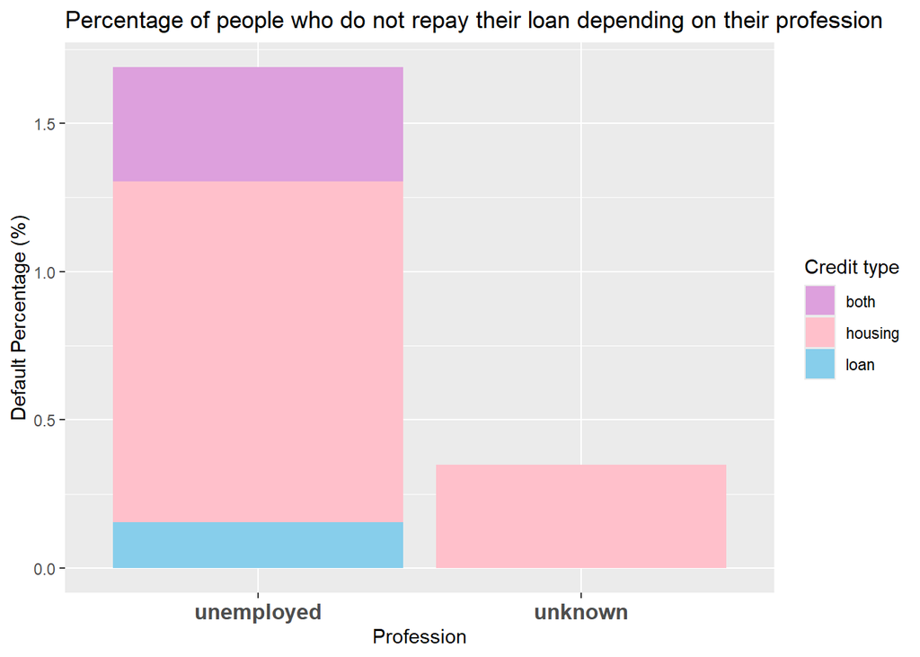

```r
df %>%
  filter(job == "unemployed"|job == "unknown") %>%
  mutate(
    which_not_repaid = case_when(
      housing == "yes" & loan == "yes" ~ "both",
      housing == "yes" & loan == "no" ~ "housing",
      housing == "no" & loan == "yes" ~ "loan",
      TRUE ~ "none"
    )) %>%
  filter(default == "yes" & which_not_repaid != "none") %>%
  group_by(job, which_not_repaid) %>%
  summarise(count = n(), .groups = "drop") %>%
  left_join(df %>% filter(job %in% c("unemployed", "unknown")) %>%
              group_by(job) %>% summarise(total = n()), by = "job") %>%
  mutate(percent = (count / total) * 100) %>%
  ggplot(aes(x = job, y = percent, fill = which_not_repaid)) +
  geom_col(position = "stack") +
   scale_fill_manual(values = c("housing" = "pink",
                               "loan" = "skyblue",
                               "both" = "plum")) +
  labs(
    title = "Percentage of people who do not repay their loan depending on their profession",
    x = "Profession",
    y = "Default Percentage (%)",
    fill = "Credit type"
  )+
  theme(axis.text.x = element_text(size = 12, face='bold'))
```

**Komentarz:** Tak, procent osób, które są bezrobotne i nie spłacają kredytu jest większy niż osób, których profesja jest nieznana i nie spłacają kredytu. Najczęściej niespłacany jest kredyt na dom.